# Coursework Report

*N* removed NAs: 5

*N* removed <18: 26

**Correct typo age:** 18

*N* total clean: 137

| Group | *N* | *M*<sub>age</sub> | % green |
| --- | --- | --- | --- |
| Control | 69 | 21.14 | 51.69 |
| Experim | 68 | 20.28 | 34.31 |

| Gender | *N* | *M*<sub>age</sub> | % green |
| --- | --- | --- | --- |
| Female | 73 | 20.38 | 46.58 |
| Male | 41 | 21.59 | 34.96 |
| Other | 23 | 20.22 | 46.38 |

**Main analysis results**

**car:**  
χ<sup>2</sup>(1) = 1.71, *p* = .192

**cleaner:**  
χ<sup>2</sup>(1) = 9.41, *p* = .002

**dishwasher:**  
χ<sup>2</sup>(1) = 1.67, *p* = .196

[interactive chart not shown]

[figure not shown]

[interactive chart not shown]

# Coursework Report

Analysing Data, Spring 2020

# Participants

Table 1. *Descriptive statistics by condition*

| Condition | Gender | *N* | % | *M*<sub>age</sub> | *SD*<sub>age</sub> |
| --- | --- | --- | --- | --- | --- |
| control | female | 99 | 28.95 | 21.33 | 2.09 |
| control | male | 45 | 13.16 | 22.73 | 2.26 |
| control | other | 36 | 10.53 | 21.00 | 1.37 |
| experimental | female | 78 | 22.81 | 20.46 | 1.53 |
| experimental | male | 66 | 19.30 | 21.45 | 2.27 |
| experimental | other | 18 | 5.26 | 20.50 | 1.42 |

# Design

In a between-subjects design, participants were asked to read a text that induced a feeling of high status, namely being in a high-class environment with the opportunity to move up in position higher than a same-sex colleague. The neutral status story for the control group instead involved searching for a concert ticket. These texts were replicated from Griskevicius et al. (2010). Participants were then asked to choose between pro-environmental and luxurious products. (*“If you were out shopping for a car/dishwasher/household cleaner, which of these two products would you buy?”*).

Conceptually, it was predicted that status motives are a driving factor for the purchasing of pro-environmental products. This would mean participants in the experimental condition would choose the green option more frequently than those in the control condition. If this is found, there would be evidence to suggest there is replicablility of results from Griskevicius et al. (2010)’s original study. The results will be analysed using a *χ*<sup>2</sup> test.

## **Results**

Table 2 *Descriptive statistics by product type*

| Condition | Product Type | Frequency |
| --- | --- | --- |
| control | luxury | 86 |
| control | green | 94 |
| experimental | luxury | 111 |
| experimental | green | 51 |

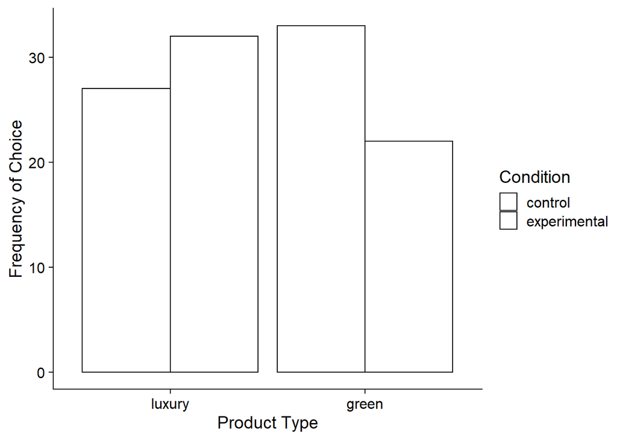

Figure 3. *Dishwasher Product Choices by Condition*

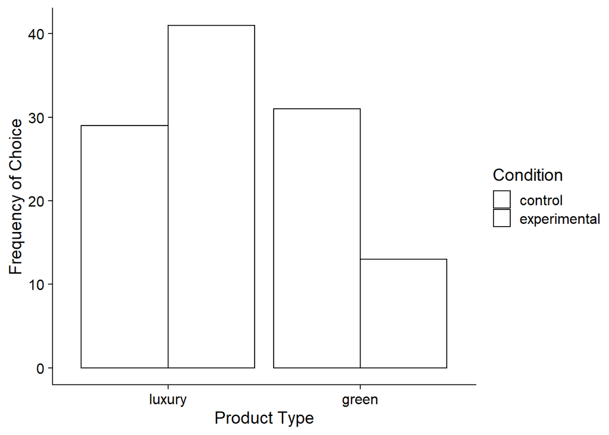

Figure 4. *Cleaner Product Choices by Condition*

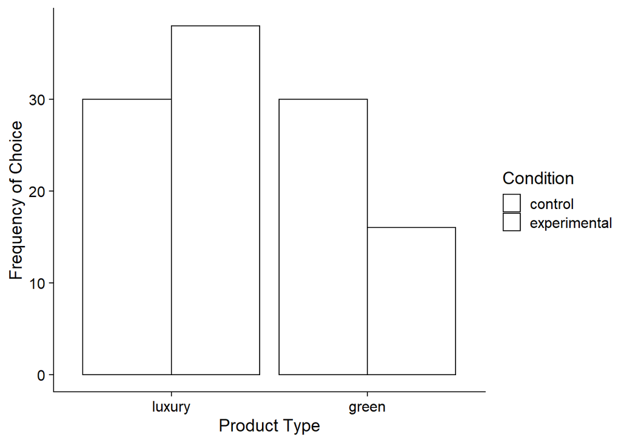

Figure 5. *Car Product Choices by Condition*

## **Discussion**

Other studies differ even further. Berger (2017) conducted a replication study in a similar vein, finding that results differ when accounting for participant difference in socioeconomic status within a field setting. No evidence was found to support the costly signalling theory. Berger (2017) postulates that this might be due to luxury items signalling wealth and prosperity that is not necessarily perceived as positive, as those with lower income might associate luxury products with inequality. Perhaps in this study, the results would also show no evidence of costly signalling with a sample in a low-income group. The use of a field experiment might also produce results with higher ecological validity than the hypothetical scenarios presented in this study.

The hypothetical nature of this study might also have implications for how participants view the products. It has been suggested, for example, that descriptions of luxury products are often more “abstract” than those of non-luxury products, said to reflect a perception of luxury goods as being further from reality than typical goods (Hansen & Wänke, 2011). Whether this increases or decreases product appeal, product perception could be a confounding variable. Participants may also be more inclined to choose luxury or green (depending on personal preference) when money is imagined to be limitless, as real life might not allow for the same opportunity. Griskevicius et al. (2010) mention that green product purchasing is altruistic due to the personal loss that comes from a product beneficial to society but is both expensive and of lower quality. Luxury goods are also expensive (Kapferer & Laurent, 2016) thus conduction of a replication study with the incorporation of cheap dishwashers, cars and cleaners in a field setting might be beneficial to investigate whether costly signalling still occurs. This would further reflect the choices that individuals typically have in their lives.

It is also vital to consider the demographics of this sample. Being mostly individuals in their early twenties, it could be argued that views on sustainable purchases might differ from those in higher age groups. Casaló and Escario (2018) claim that whilst older individuals tend to engage in more pro-environmental behaviours, younger peoples’ attitudes are generally more pro-environmental. This might imply that this difference might not influence product choice in a field setting, particularly when accounting for misalignment between actions and beliefs (Broom, 2017), but might be relevant for this hypothetical choice study.

## **References**

Berger, J. (2017). Are Luxuy Brand Labels and “Green” Labels Costly Signals of Social Status? An Extended Replication. *PLoS One, 12*(2).

Broom, C. (2017). Exploring the Relations Between Childhood Experiences in Nature and Young Adults’ Environmental Attitudes and Behaviours. *Australian Journal of Environmental Education, 33*(1). 34-47.

Brun, A., & Castelli, C. (2013). The nature of luxury: a consumer perspective. *International Journal of Retail & Distribution Management, 41*. 823-847.

Casaló, L. V., & Escario, J. (2018). Heterogeneity in the association between environmental attitudes and pro-environmental behavior: A multilevel regression approach. *Journal of Cleaner Production, 175*. 155-163.

Griskevicius, V., Tybur, J. M., & Van den Bergh, B. (2010). Going green to be seen: Status, reputation, and conspicuous conservation. *Journal of Personality and Social Psychology, 98*(3). 392-404.

Hansen, J., & Wänke, M. (2011). The abstractness of luxury. *Journal of Economic Psychology, 32*(11). 789-796.

Kapferer, J. N., & Laurent, G. (2016). Where do consumers think luxury begins? A study of perceived minimum price for 21 luxury goods in 7 countries. *Journal of Business Research, 69*(1). 332-340.